# Where Does The Buck Stop? Economic Conditions & Electoral Volatility

Karnav Popat

26/04/2024

## Research Question

We know that voters punish incumbents when the economy goes sour. At what level of governance do voters allocate responsibility for economic underperformance? Any voter in India is under atleast three levels of governance: local representation, state government, and central government. In the United States, where popular perception of control is focused on the President, voters tend to punish the President’s party. Does this hold true for India, where economic initiative is (or was) significantly more decentralized?

## Dependent Variable

To measure how voters reward and punish retrospective economic conditions, we use electoral volatility. We can calculate this for each constituency and each election using TCPD’s assembly election dataset.

The dataset contains a number of electoral indicators which are calculated at the constituency level, rather than being specific to candidate or party. These are the voter turnout (which indicates the level of democratic participation) and Effective Number of Parties (ENOP, which indicates the effective degree of choice that the voter has). They are simple measures of voting behaviour which we will use these as controls while studying the impact of the economy on electoral volatility.

Aggregate Electoral Indicators

| State_Name | Year | Constituency_No | Constituency_Name | total_votes | Electors | Turnout_Percentage | ENOP |
| --- | --- | --- | --- | --- | --- | --- | --- |
| Andhra_Pradesh | 1962 | 1 | ICHAPURAM | 34204 | 60344 | 56.68 | 1.89 |
| Andhra_Pradesh | 1962 | 2 | SOMPETA | 38091 | 62237 | 61.20 | 2.70 |
| Andhra_Pradesh | 1962 | 3 | BRAHMANATARLA | 33633 | 64597 | 52.07 | 5.00 |
| Andhra_Pradesh | 1962 | 4 | TEKKALI | 37978 | 64913 | 58.51 | 1.89 |
| Andhra_Pradesh | 1962 | 5 | NARASANNAPETA | 36701 | 59218 | 61.98 | 1.96 |
| Andhra_Pradesh | 1962 | 6 | PATAPATNAM | 34226 | 57185 | 59.85 | 2.78 |

| x |
| --- |
| 54522 |

More comprehensive measures of voting behaviour are calculated from one election to another. We calculate four measures of changing voter behaviour between elections:

- Change in Incumbent Party’s Voteshare
- Change in State-ruling Party’s Voteshare
- Change in Central-ruling Party’s Voteshare
- Electoral Volatility

The first three are simple to calculate: they are simply the change in the percentage voteshare received by each type of party between one election and the next.  
To accomplish this, we first create binary variables holding the status of each party (whether it won, or was incumbent in, that constituency or state election).

```r
# Aggregate the data by party instead of by candidate, filter elections before 1980
partywise_votes <- assembly %>%
  filter(Year >= 1980)%>%
  mutate(is_winner = ifelse(Position == 1, 1, 0))%>%

  group_by(State_Name, Constituency_No, Constituency_Name, Year, Assembly_No, Party)%>%
  summarize(Votes=sum(Votes), Valid_Votes=sum(Valid_Votes), Electors=first(Electors), Turnout=first(Turnout_Percentage), Constituency_Type=first(Constituency_Type), Vote_Share_Percentage=sum(Vote_Share_Percentage), ENOP=first(ENOP), is_winner=first(is_winner))%>%
  ungroup()
```

Summary Statistics

| Variable | N | Mean | Std. Dev. | Min | Pctl. 25 | Pctl. 75 | Max |
| --- | --- | --- | --- | --- | --- | --- | --- |
| Constituency_No | 243762 | 116 | 93 | 1 | 40 | 175 | 425 |
| Year | 243762 | 2003 | 13 | 1980 | 1993 | 2014 | 2023 |
| Assembly_No | 243762 | 11 | 3.9 | 1 | 8 | 14 | 18 |
| Votes | 243733 | 15965 | 23039 | -1 | 891 | 24503 | 584098 |
| Valid_Votes | 243762 | 178924 | 292735 | -1 | 81122 | 171801 | 19579792 |
| Electors | 243550 | 180583 | 90289 | 0 | 125966 | 228035 | 1593907 |
| Turnout | 243549 | 65 | 14 | -0.01 | 56 | 75 | 736 |
| Constituency_Type | 243762 |  |  |  |  |  |  |
| … | 2 | 0% |  |  |  |  |  |
| … BL | 191 | 0% |  |  |  |  |  |
| … GEN | 185243 | 76% |  |  |  |  |  |
| … SC | 35425 | 15% |  |  |  |  |  |
| … ST | 22901 | 9% |  |  |  |  |  |
| Vote_Share_Percentage | 243617 | 16 | 19 | 0 | 0.81 | 31 | 100 |
| ENOP | 243617 | 3.1 | 1.1 | 1 | 2.3 | 3.6 | 14 |
| is_winner | 243762 | 0.16 | 0.36 | 0 | 0 | 0 | 1 |

```r
# Flag winners and incumbents at all three levels
partywise_votes <- partywise_votes%>%
  group_by(State_Name, Assembly_No, Party)%>%
  mutate(seats=sum(is_winner))%>%
  ungroup()%>%

  group_by(State_Name, Assembly_No)%>%
  mutate(state_winner = ifelse(seats == max(seats), 1, 0))%>%
  ungroup()%>%

  mutate(nat_winner = case_when(
    (Year >= 1947 & Year <= 1971 & Party == "INC") ~ 1,
    (Year > 1971 & Year < 1977 & Party == "INC(I)") ~ 1,
    (Year >= 1977 & Year < 1980 & Party == "JNP") ~ 1,
    (Year >= 1980 & Year <= 1989 & Party == "INC") ~ 1,
    (Year > 1989 & Year < 1991 & Party == "JD") ~ 1,
    (Year >= 1991 & Year < 1996 & Party == "INC") ~ 1,
    (Year >= 1991 & Year < 1996 & Party == "INC") ~ 1,
    (Year >= 1996 & Year < 1998 & Party == "JD") ~ 1,
    (Year >= 1998 & Year < 2004 & Party == "BJP") ~ 1,
    (Year >= 2004 & Year < 2014 & Party == "INC") ~ 1,
    (Year >= 2014 & Year < 2024 & Party == "BJP") ~ 1,
    TRUE ~ 0
  ))%>%

  group_by(State_Name, Constituency_No, Constituency_Name, Party)%>%
  mutate(is_incumbent = replace_na(dplyr::lag(is_winner, n=1), 0))%>%
  mutate(state_incumbent = replace_na(dplyr::lag(state_winner, n=1), 0))%>%
  mutate(nat_incumbent = replace_na(dplyr::lag(nat_winner, n=1), 0))%>%
  ungroup()
```

We can then create columns to store the voteshare of the winning and incumbent party at both levels for each election.

```r
# Create columns for the voteshares of the respective incumbent parties
partywise_votes <- partywise_votes%>%
  mutate(Winning_Party = ifelse(is_winner == 1, Vote_Share_Percentage, 0))%>%
  mutate(State_Win_Party = ifelse(state_winner == 1, Vote_Share_Percentage, 0))%>%
  mutate(Nat_Win_Party = ifelse(nat_winner == 1, Vote_Share_Percentage, 0))%>%
  mutate(Incumbent_Party = ifelse(is_incumbent == 1, Vote_Share_Percentage, 0))%>%
  mutate(State_Incumb_Party = ifelse(state_incumbent == 1, Vote_Share_Percentage, 0))%>%
  mutate(Nat_Incumb_Party = ifelse(nat_incumbent == 1, Vote_Share_Percentage, 0))
```

For further calculations, we’ll first have to pivot the dataframe wider, creating a unique column for each unique party holding its voteshare in each election.

```r
# Extract the list of parties
party_list <- as.list(unique(partywise_votes$Party))

# Widen the dataframe for each party
for (party in party_list) {
  partywise_votes[[paste0("Party_", party)]] <- ifelse(partywise_votes$Party == party, partywise_votes$Vote_Share_Percentage, 0)
}

partywise_votes <- partywise_votes%>%
  dplyr::select(-Party, -Votes, -Valid_Votes, -seats)%>%
  group_by(State_Name, Constituency_No, Constituency_Name, Assembly_No, Year, Electors, Turnout, Constituency_Type, ENOP)%>%
  summarise_all(.funs = function(x) sum(x))%>%
  ungroup()
```

We can now calculate our final measure. Electoral Volatility is represented by the Pedersen index:
$$\frac{\sum_{p=1}^{n}V_{pt} - V_{p(t-1)}}{2}$$
for each party *p* between election *t* and *t-1*. We can calculate this from our wide dataframe as follows:

```r
# Calculate the change in voteshare for each party between each pair of elections
partywise_deltas <- partywise_votes%>%
  group_by(State_Name, Constituency_No, Constituency_Name)%>%

  mutate_at(vars(starts_with("Party_")),
            funs(abs(. - dplyr::lag(.))))%>%
  mutate_all(~replace(., is.na(.), 0))%>%
  mutate_at(vars(matches("^Party")), as.numeric)%>%
  ungroup()

write.csv(partywise_deltas, "./data/partywise_deltas.csv", row.names=FALSE)
```

```r
# Calculate the volatility by summing the deltas for each party
# Also rename the incumbent voteshare columns
partywise_deltas <- partywise_deltas%>%
  group_by(State_Name, Constituency_No, Constituency_Name)%>%

  mutate(incumb_share = replace_na(Incumbent_Party, 0))%>%
  mutate(state_incumb_share = replace_na(State_Incumb_Party, 0))%>%
  mutate(nat_incumb_share = replace_na(Nat_Incumb_Party, 0))%>%
  ungroup()%>%

  mutate(volatility=rowSums(dplyr::select(., starts_with("Party_")))/2)

volatility <- partywise_deltas%>%
  dplyr::select(State_Name, Constituency_No, Constituency_Name, Year, Assembly_No, Electors, Turnout, ENOP, volatility, incumb_share, state_incumb_share, nat_incumb_share)
```

Summary Statistics

| Variable | N | Mean | Std. Dev. | Min | Pctl. 25 | Pctl. 75 | Max |
| --- | --- | --- | --- | --- | --- | --- | --- |
| Constituency_No | 38522 | 111 | 91 | 1 | 37 | 169 | 425 |
| Year | 38522 | 2000 | 13 | 1980 | 1990 | 2012 | 2023 |
| Assembly_No | 38522 | 10 | 3.7 | 1 | 8 | 13 | 18 |
| Electors | 38522 | 157402 | 86236 | 0 | 106094 | 203218 | 1593907 |
| Turnout | 38522 | 66 | 15 | -0.01 | 57 | 76 | 736 |
| ENOP | 38522 | 2.9 | 1 | 0 | 2.2 | 3.3 | 14 |
| volatility | 38522 | 30 | 27 | 0 | 2.3 | 50 | 100 |
| incumb_share | 38522 | 25 | 23 | 0 | 0 | 45 | 100 |
| state_incumb_share | 38522 | 22 | 22 | 0 | 0 | 41 | 100 |
| nat_incumb_share | 38522 | 16 | 20 | 0 | 0 | 35 | 100 |

This gives us our dependent variable, electoral volatility, at the constituency level.

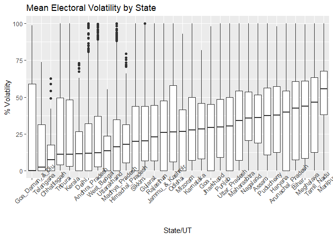

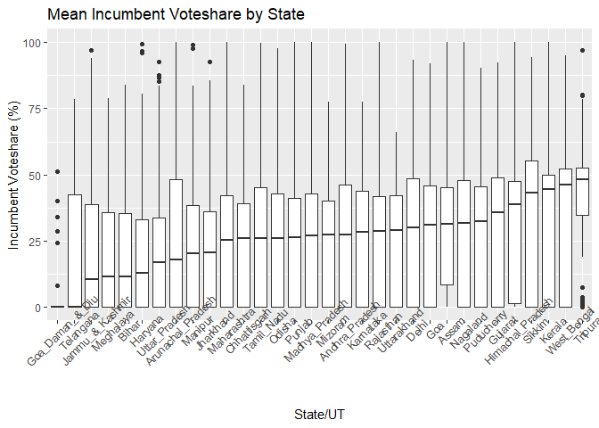

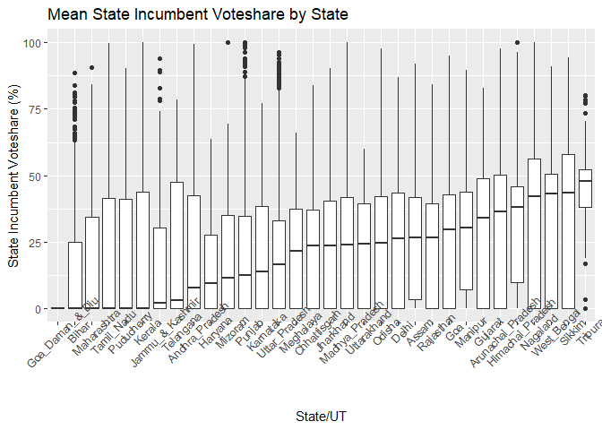

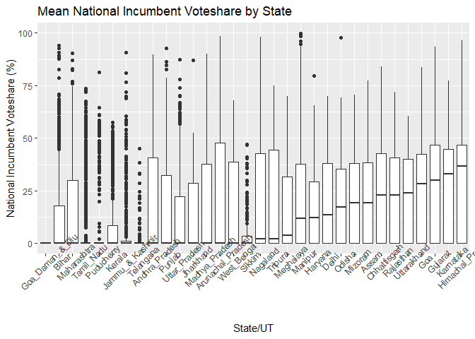

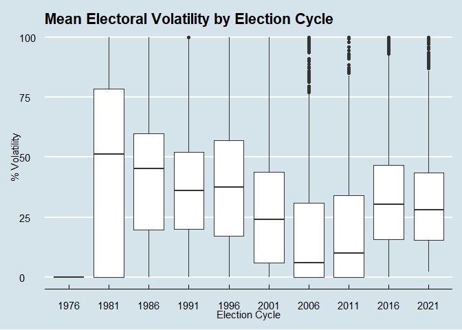

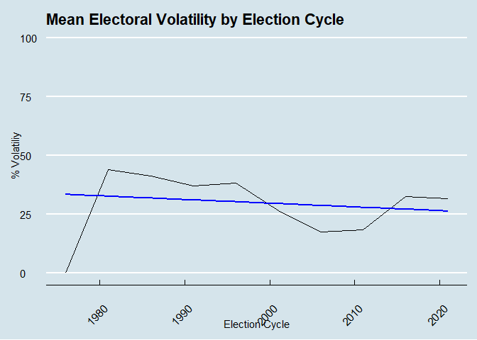

Similarly, looking at anti-incumbency by year, there seems to be a pronounced decrease in the intensity of the effect in recent times. The effect was strongest during the period of electoral turmoil in the 80s with the contest between the Congress and the Janata Party, and slowly decreased from then on. This is consistent with the temporal trend we observed in volatility, since a decline in one would correspond to the other as people become more fixed in their voting preferences.

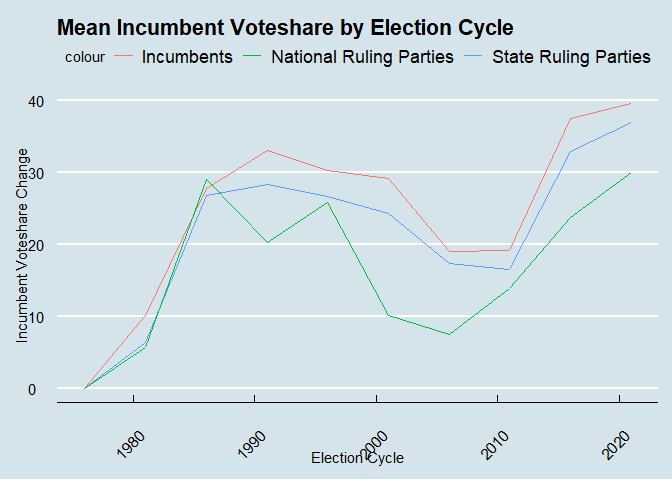

## Independent Variable

To measure nationwide economic conditions over time, we use night-lights data as a proxy. This is a well-established though inherently limited practice. We can get night-lights data from SHRUG, which is divided on either side of 2013 into two different satellites’ data. We therefore use the Li harmonized nightlights dataset.

We first clip the nightlights raster data to the extent of our two Indian assembly constituency shapefiles (before and after the 2008 delimitation).

```r
ext_old <- extent(assembly_shp_old)
ext <- extent(assembly_shp)

nightlights_old <- assembly_shp_old %>%
  dplyr::select(state=State, ac_no=AC_NO, ac_name=AC_NAME)
nightlights <- assembly_shp %>%
  dplyr::select(state, ac_no=ac, ac_name)
```

We can then extract the mean nightlights (luminosity) value to each constituency, creating a constituency nightlights dataframe in wide format.

```r
# Before delimitation, old satellite
for (i in 1992:2007) {
  rasterfile <- raster(paste0("../shrug/li/clipped_", as.character(i), "_calDMSP.tif"))
  nightlights_old[paste0("ng_", as.character(i))] <- exact_extract(rasterfile, assembly_shp_old, 'mean', progress=FALSE)
}
```

```r
# After delimitation, old satellite
for (i in 2008:2013) {
  rasterfile <- raster(paste0("../shrug/li/clipped_", as.character(i), "_calDMSP.tif"))
  nightlights[paste0("ng_", as.character(i))] <- exact_extract(rasterfile, assembly_shp, 'mean', progress=FALSE)
}
# st_write(nightlights_old, "./data/nightlights_old.shp", delete_dsn = T)
```

```r
# After delimitation, new satellite
for (i in 2014:2021) {
  rasterfile <- raster(paste0("../shrug/li/clipped_", as.character(i), "_simVIIRS.tif"))
  nightlights[paste0("ng_", as.character(i))] <- exact_extract(rasterfile, assembly_shp, 'mean', progress=FALSE)
}
# st_write(nightlights, "./data/nightlights_new.shp", delete_dsn = T)
```

We now have a (long) constituency-over-years dataset of our dependent variable, electoral volatility, and a (wide) constituency-over-years dataset of our independent variable, nightlights, which we can clean and merge together.  
To do so, we first pivot the nightlights data to long format, then clean it to prepare for constructing our panel dataset.

```r
nightlights <- nightlights%>%
  mutate(ng_2014 = 0.65*ng_2014)%>%
  mutate(ng_2015 = 0.55*ng_2015)%>%
  mutate(ng_2015 = 5*ng_2016)%>%
  mutate(ng_2021 = 0.75*ng_2021)

nightlights_old <- nightlights_old%>%
  pivot_longer(cols = starts_with("ng_"),
                          names_to = "delta_year",
                          values_to = "nightlights")%>%
  mutate(delta_year = gsub("ng_", "", delta_year))

nightlights <- nightlights%>%
  pivot_longer(cols = starts_with("ng_"),
                          names_to = "delta_year",
                          values_to = "nightlights")%>%
  mutate(delta_year = gsub("ng_", "", delta_year))
```

```r
nightlights <- rbind(nightlights_old, nightlights)

nightlights <- nightlights%>%
  mutate(delta_year = as.numeric(delta_year))%>%
  mutate(ac_no = as.numeric(ac_no))%>%
  mutate(state = gsub(" ", "_", state))%>%
  mutate(ac_name = gsub(" ", "_", ac_name))%>%
  mutate(state = str_to_upper(state))%>%
  mutate(ac_name = str_to_upper(ac_name))%>%
  mutate(state = gsub("ORISSA", "ODISHA", state))%>%
  mutate(state = gsub("TAMILNADU", "TAMIL_NADU", state))%>%
  mutate(state = gsub("UTTARANCHAL", "UTTARAKHAND", state))%>%
  mutate(state = if_else((delta_year < 2000) & (state == "UTTARAKHAND"), "UTTAR_PRADESH", state))%>%
  mutate(state = if_else((delta_year < 2000) & (state == "CHHATTISGARH"), "MADHYA_PRADESH", state))%>%
  mutate(state = if_else((delta_year < 2000) & (state == "JHARKHAND"), "BIHAR", state))%>%
  mutate(state = if_else((delta_year < 2014) & (state == "TELANGANA"), "ANDHRA_PRADESH", state))%>%
  arrange(state, ac_name, delta_year)

st_write(nightlights, "./data/nightlights.shp", delete_dsn = T)
```

Nightlights Data

| state | ac_name | ng_2008 | ng_2021 | geometry |
| --- | --- | --- | --- | --- |
| Telangana | Sirpur | 1.950624 | 7.792569 | MULTIPOLYGON (((79.55699 19… |
| Telangana | Chennur | 4.220965 | 11.604282 | MULTIPOLYGON (((79.90563 19… |
| Telangana | Bellampalli | 4.106324 | 9.460627 | MULTIPOLYGON (((79.908 19.1… |
| Telangana | Mancherial | 10.471242 | 16.960398 | MULTIPOLYGON (((79.10574 19… |
| Telangana | Asifabad | 3.475947 | 7.919819 | MULTIPOLYGON (((78.73274 19… |
| Telangana | Khanapur | 5.721958 | 8.795670 | MULTIPOLYGON (((78.59774 19… |
| Telangana | Adilabad | 8.101927 | 11.853553 | MULTIPOLYGON (((78.59774 19… |
| Telangana | Boath | 5.354019 | 9.051396 | MULTIPOLYGON (((78.51174 19… |
| Telangana | Nirmal | 8.248992 | 12.583598 | MULTIPOLYGON (((78.16924 19… |
| Telangana | Mudhole | 5.712011 | 10.087209 | MULTIPOLYGON (((78.16924 19… |

| x |
| --- |
| 4074 |

Summary Statistics

| Variable | N | Mean | Std. Dev. | Min | Pctl. 25 | Pctl. 75 | Max |
| --- | --- | --- | --- | --- | --- | --- | --- |
| ac_no | 122780 | 103 | 85 | 0 | 35 | 157 | 403 |
| delta_year | 122780 | 2006 | 8.7 | 1992 | 1999 | 2014 | 2021 |
| nightlights | 122764 | 13 | 20 | 0 | 2.3 | 13 | 221 |

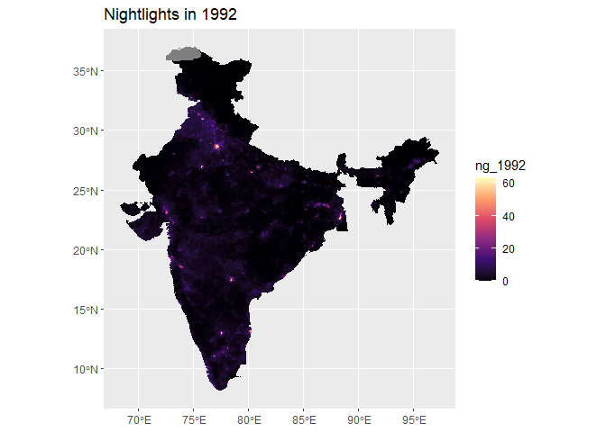

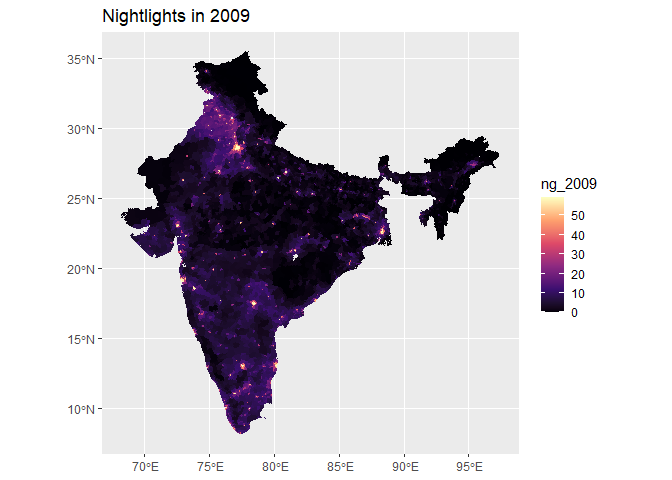

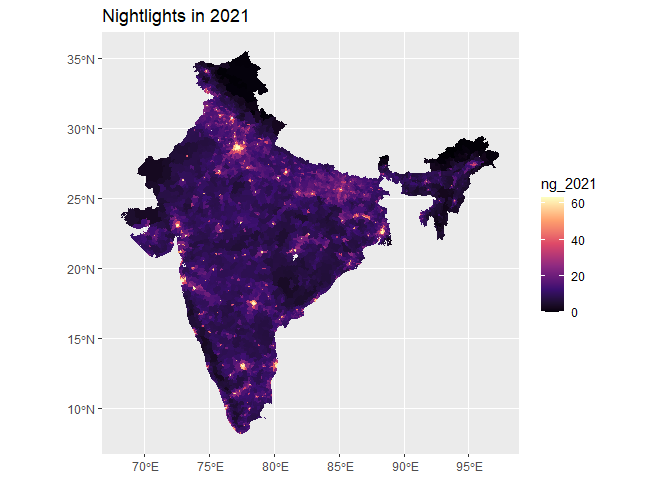

Now that we have both datasets in long format, we can merge the two together to create a single panel dataset on which we can run our fixed-effects model. We merge every year individually because of the large amount of constituency changes between years because of delimitation, creation of states, etc.

```r
volatility <- volatility%>%
  filter(volatility > 0)%>%
  mutate(election_year = as.numeric(Year))%>%
  mutate(Constituency_No = as.numeric(Constituency_No))%>%
  mutate(Assembly_No = as.numeric(Assembly_No))%>%
  mutate(State_Name = gsub(" ", "_", State_Name))%>%
  mutate(Constituency_Name = gsub(" ", "_", Constituency_Name))%>%
  mutate(State_Name = str_to_upper(State_Name))%>%
  mutate(Constituency_Name = str_to_upper(Constituency_Name))%>%
  mutate(State_Name = gsub("ORISSA", "ODISHA", State_Name))%>%
  arrange(State_Name, Constituency_Name)
```

```r
volatility_year <- volatility%>%
  filter(election_year == 1990)

panel_data <- stringdist_join(nightlights, volatility_year, method="lcs", mode="inner", distance_col = "distance", by = c("state" = "State_Name", "ac_name" = "Constituency_Name"))%>%
  group_by("state", "ac_name")%>%
  slice_min(order_by=distance, n=1)%>%
  ungroup()%>%
  filter(election_year >= delta_year)

for (i in 1991:2021) {
  volatility_year <- volatility%>%
    filter(election_year == i)

  data <- stringdist_join(nightlights, volatility_year, method="lcs", mode="inner", distance_col = "distance", by = c("state" = "State_Name", "ac_name" = "Constituency_Name"))%>%
  group_by("state", "ac_name")%>%
  slice_min(order_by=distance, n=1)%>%
  ungroup()%>%
  filter(election_year >= delta_year)

  panel_data <- rbind(panel_data, data)
}
```

```r
panel_data <- st_drop_geometry(panel_data)

panel <- panel_data%>%
  dplyr::select(state, ac_no, ac_name, delta_year, nightlights, Constituency_No, Constituency_Name, election_year, Assembly_No, Electors, Turnout, ENOP, volatility, incumb_share, state_incumb_share, nat_incumb_share)%>%
  filter(!is.na(nightlights))%>%
  distinct(state, ac_no, ac_name, election_year, delta_year, .keep_all = TRUE)%>%
  arrange(state, ac_name, election_year)
```

We then calculate our final independent variable metrics (relative and absolute changes in nightlights over differing time periods).

```r
panel <- panel%>%
  group_by(delta_year)%>%
  mutate(mean_nightlights = mean(nightlights))%>%
  ungroup()%>%

  group_by(state, ac_name)%>%
  mutate(percent_change = ((nightlights - dplyr::lag(nightlights, n=1))/dplyr::lag(nightlights, n=1)) * 100)%>%

  mutate(percent_change_3 = ((nightlights - dplyr::lag(nightlights, n=3))/dplyr::lag(nightlights, n=3)) * 100)%>%

  group_by(state, ac_name)%>%
  mutate(percent_change_t = ((nightlights - dplyr::lag(nightlights, n=5))/dplyr::lag(nightlights, n=5)) * 100)%>%
  ungroup()%>%

  mutate(past_three = rollmean(nightlights, k = 3, fill = NA, align = "right"))%>%
  mutate(percent_change_p3 = ((past_three - dplyr::lag(past_three))/dplyr::lag(past_three)) * 100)%>%

  mutate(percent_change_p3_3 = ((past_three - dplyr::lag(past_three, n=3))/dplyr::lag(past_three, n=3)) * 100)%>%

  mutate(percent_change_p3_t = ((past_three - dplyr::lag(past_three, n=5))/dplyr::lag(past_three, n=5)) * 100)%>%
  ungroup()
```

We can also calculate the other variables which could impact electoral volatility (changes in ENOP, Turnout, etc), which we’ll use as controls.

```r
panel <- panel%>%
  filter(delta_year == (election_year-1))%>%

  group_by(state, ac_name)%>%
  mutate(delta_ENOP = ENOP - dplyr::lag(ENOP, n=1))%>%
  mutate(delta_Turnout = Turnout - dplyr::lag(Turnout, n=1))%>%
  ungroup()%>%

  filter(!is.na(percent_change))%>%
  filter(is.finite(percent_change))%>%
  filter(!is.na(percent_change_3))%>%
  filter(is.finite(percent_change_3))%>%
  filter(!is.na(percent_change_p3))%>%
  filter(is.finite(percent_change_p3))%>%
  filter(!is.na(percent_change_t))%>%
  filter(is.finite(percent_change_t))%>%
  filter(!is.na(volatility))%>%
  filter(is.finite(volatility))
```

We eliminate outliers caused by low-value nightlights data and data errors, which gives us our final panel dataset.

```r
write.csv(panel, "./data/panel_dataset_with_outliers.csv", row.names=FALSE)
panel_with_outliers <- panel

Q1_1 <- quantile(panel$percent_change_p3, .25)
Q3_1 <- quantile(panel$percent_change_p3, .75)
IQR_1 <- IQR(panel$percent_change_p3)

Q1_2 <- quantile(panel$percent_change_p3_t, .25)
Q3_2 <- quantile(panel$percent_change_p3_t, .75)
IQR_2 <- IQR(panel$percent_change_p3_t)

panel <- panel%>%
  filter((percent_change_p3 > (Q1_1 - 1.25*IQR_1)) & (percent_change_p3 < (Q3_1 + 1.25*IQR_1)))%>%
  filter((percent_change_p3_t > (Q1_2 - 1.25*IQR_2)) & (percent_change_p3_t < (Q3_2 + 1.25*IQR_2)))%>%
  mutate(state = gsub("_", " ", state))%>%
  mutate(state = gsub("&", " ", state))

write.csv(panel, "./data/panel_dataset.csv", row.names=FALSE)
```

| state | ac_name | election_year | volatility | delta_year | nightlights |
| --- | --- | --- | --- | --- | --- |
| ANDHRA PRADESH | ACHAMPET | 1999 | 21.005 | 1998 | 1.709240 |
| ANDHRA PRADESH | ACHAMPET | 2004 | 18.950 | 2003 | 1.943651 |
| ANDHRA PRADESH | ACHANTA | 2004 | 16.120 | 2003 | 7.402138 |
| ANDHRA PRADESH | ADDANKI | 1999 | 54.330 | 1998 | 4.923980 |
| ANDHRA PRADESH | ADDANKI | 2004 | 2.565 | 2003 | 5.721539 |
| ANDHRA PRADESH | ADILABAD | 1999 | 24.390 | 1998 | 3.927750 |
| ANDHRA PRADESH | ADILABAD | 2004 | 43.215 | 2003 | 4.616456 |
| ANDHRA PRADESH | ADONI | 1999 | 5.905 | 1998 | 3.543146 |
| ANDHRA PRADESH | ADONI | 2004 | 22.125 | 2003 | 3.138883 |
| ANDHRA PRADESH | ALAIR | 1999 | 27.285 | 1998 | 6.202911 |

| x |
| --- |
| 10292 |

Summary Statistics

| Variable | N | Mean | Std. Dev. | Min | Pctl. 25 | Pctl. 75 | Max |
| --- | --- | --- | --- | --- | --- | --- | --- |
| ac_no | 10292 | 100 | 81 | 1 | 34 | 150 | 403 |
| delta_year | 10292 | 2006 | 7.6 | 1994 | 2000 | 2013 | 2020 |
| nightlights | 10292 | 13 | 16 | 0 | 3.2 | 14 | 63 |
| Constituency_No | 10292 | 103 | 85 | 1 | 35 | 155 | 424 |
| election_year | 10292 | 2007 | 7.6 | 1995 | 2001 | 2014 | 2021 |
| Assembly_No | 10292 | 11 | 3 | 2 | 9 | 13 | 17 |
| Electors | 10292 | 175874 | 84875 | 0 | 135550 | 218240 | 1593907 |
| Turnout | 10292 | 68 | 13 | 0 | 60 | 77 | 108 |
| ENOP | 10292 | 2.9 | 0.89 | 0 | 2.2 | 3.2 | 11 |
| volatility | 10292 | 34 | 20 | 0.62 | 17 | 48 | 100 |
| incumb_share | 10292 | 37 | 18 | 0 | 28 | 49 | 100 |
| state_incumb_share | 10292 | 32 | 20 | 0 | 17 | 47 | 100 |
| nat_incumb_share | 10292 | 22 | 21 | 0 | 0 | 41 | 100 |
| mean_nightlights | 10292 | 11 | 4.8 | 6.5 | 8.1 | 15 | 60 |
| percent_change | 10292 | 6 | 241 | -100 | -8.5 | 11 | 18865 |
| percent_change_3 | 10292 | 17 | 57 | -100 | -1.2 | 30 | 4856 |
| percent_change_t | 10292 | 32 | 564 | -100 | -1.4 | 45 | 55518 |
| past_three | 10292 | 14 | 20 | 0.0023 | 3.1 | 14 | 116 |
| percent_change_p3 | 10292 | 3.9 | 7.4 | -16 | -0.37 | 8.3 | 27 |
| percent_change_p3_3 | 10292 | 20 | 45 | -97 | -0.34 | 31 | 1538 |
| percent_change_p3_t | 10292 | 32 | 54 | -100 | 0.012 | 55 | 206 |
| delta_ENOP | 9398 | -0.064 | 0.96 | -8 | -0.48 | 0.36 | 8.1 |
| delta_Turnout | 9398 | 0.44 | 12 | -661 | -3.7 | 5.3 | 98 |
| cycle | 10292 | 2005 | 7.9 | 1991 | 2001 | 2011 | 2021 |

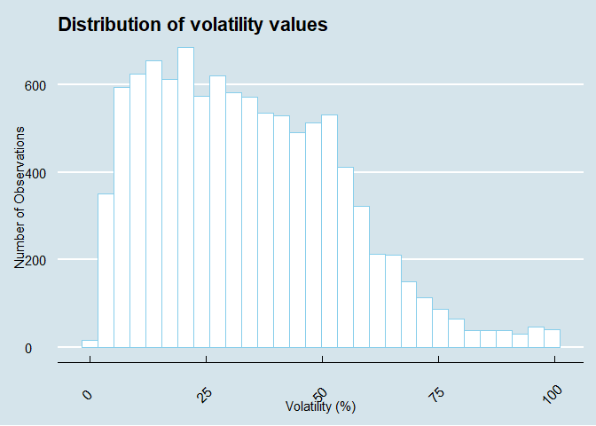

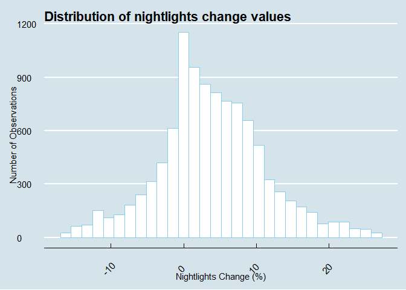

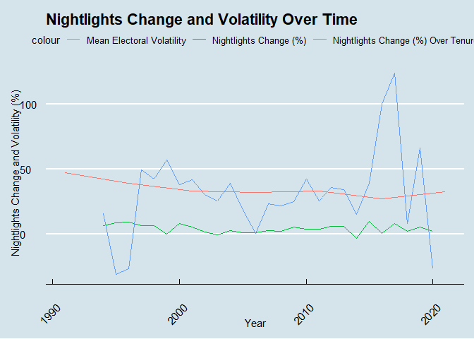

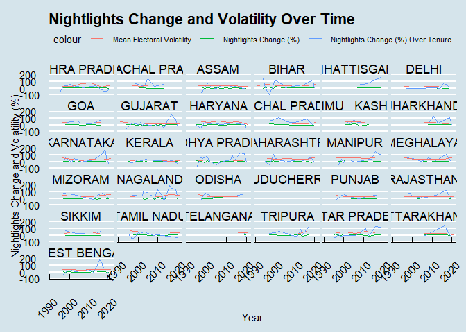

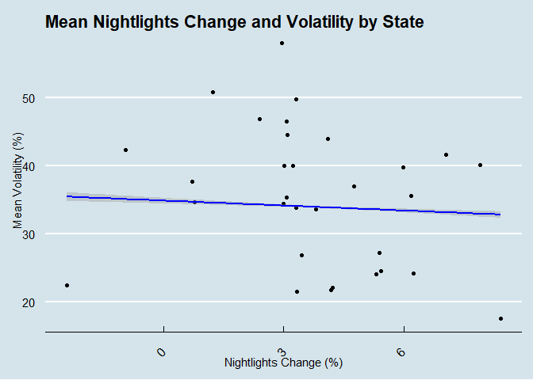

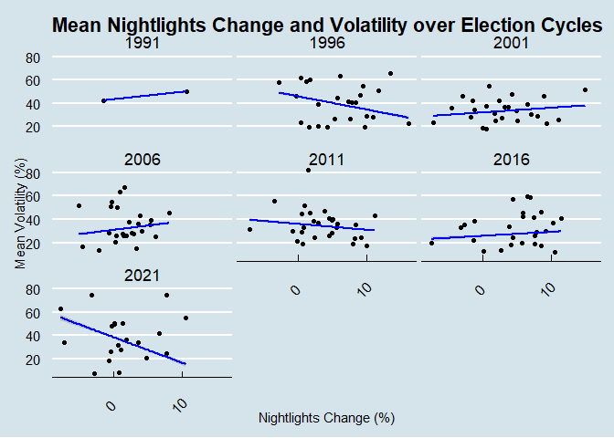

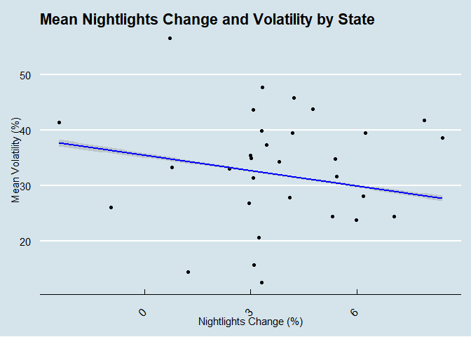

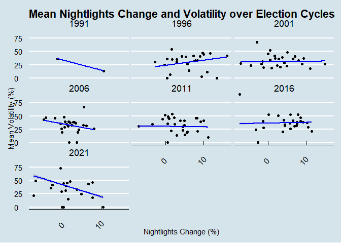

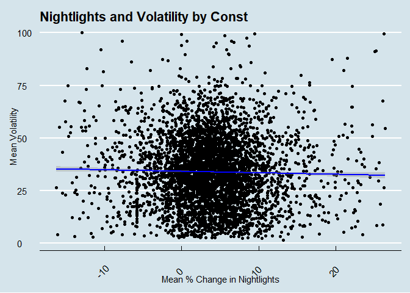

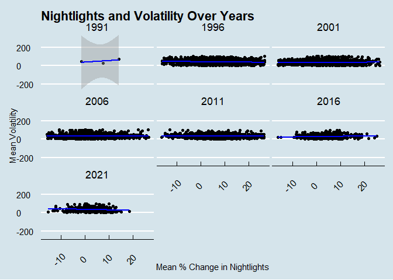

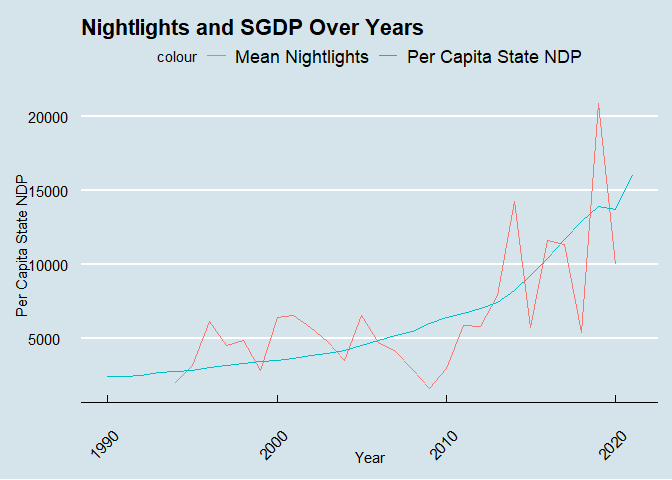

```r
temp_vol <- volatility%>%
  group_by(State_Name, election_year)%>%
  summarise(volatility = mean(volatility))

temp_panel <- inner_join(sndp, temp_vol, by=c("state" = "State_Name", "delta_year" = "election_year"))
kable(head(temp_panel, 20))
```

| l.N | State.U.T. | delta_year | pc_sndp | state | volatility |
| --- | --- | --- | --- | --- | --- |
| 21 | Sikkim | 1994 | 3715.387 | SIKKIM | 51.44422 |
| 21 | Sikkim | 1999 | 4432.249 | SIKKIM | 20.77313 |
| 21 | Sikkim | 2004 | 5672.507 | SIKKIM | 44.92722 |
| 21 | Sikkim | 2009 | 12916.484 | SIKKIM | 43.68000 |
| 21 | Sikkim | 2014 | 19730.839 | SIKKIM | 44.50935 |
| 21 | Sikkim | 2017 | 33259.533 | SIKKIM | 19.32500 |
| 21 | Sikkim | 2019 | 40264.641 | SIKKIM | 21.63203 |
| 27 | Delhi | 1993 | 6238.000 | DELHI | 11.81500 |
| 27 | Delhi | 1998 | 8159.603 | DELHI | 25.08721 |
| 27 | Delhi | 2003 | 9897.837 | DELHI | 19.65754 |
| 27 | Delhi | 2013 | 19952.709 | DELHI | 38.62250 |
| 27 | Delhi | 2015 | 24754.555 | DELHI | 27.32326 |
| 27 | Delhi | 2017 | 30466.577 | DELHI | 69.86000 |
| 27 | Delhi | 2020 | 33449.731 | DELHI | 12.29300 |
| 5 | Goa | 1994 | 5636.102 | GOA | 37.14842 |
| 5 | Goa | 1996 | 6867.432 | GOA | 55.09000 |
| 5 | Goa | 1999 | 8422.780 | GOA | 42.75100 |
| 5 | Goa | 2002 | 10512.290 | GOA | 32.72657 |
| 5 | Goa | 2005 | 8646.784 | GOA | 37.32400 |
| 5 | Goa | 2007 | 9314.299 | GOA | 28.37671 |

```r
model_rc <- plm(volatility ~ pc_sndp + delta_year + factor(state), data = temp_panel, index=c("state", "delta_year"), model="within")

stargazer(model_rc, type="text", report=("vcsp*"), omit=c("state", "delta_year"))
```

```
##
## ========================================
##                  Dependent variable:
##              ---------------------------
##                      volatility
## ----------------------------------------
## pc_sndp                -0.0003
##                       (0.0004)
##                       p = 0.446
##
## ----------------------------------------
## Observations             336
## R2                      0.137
## Adjusted R2            -0.033
## F Statistic     1.385* (df = 32; 280)
## ========================================
## Note:        *p<0.1; **p<0.05; ***p<0.01
```

We now implement our empirical strategy. Our independent variable is represented by three measures:

- Relative change in nightlights in the preceding year
- Relative change in nightlights in the preceding 3 years
- Relative change in nightlights since the last election

Our dependent variable is represented by four measures:

- Change in Incumbent Party’s Voteshare
- Change in State-ruling Party’s Voteshare
- Change in Central-ruling Party’s Voteshare
- Electoral Volatility

We’ll use a fixed-effects model controlling for state, year, and non-economic determinants to look at the effect.

```r
model_rc <- plm(volatility ~ percent_change_p3 + election_year + factor(state), data = panel, index=c("state", "ac_name", "election_year"), model="within")

model_rc2 <- plm(incumb_share ~ percent_change_p3 + election_year + factor(state), data = panel, index=c("state", "ac_name", "election_year"), model="within")

model_rc3 <- plm(state_incumb_share ~ percent_change_p3 + election_year + factor(state), data = panel, index=c("state", "ac_name", "election_year"), model="within")

model_rc4 <- plm(nat_incumb_share ~ percent_change_p3 + election_year + factor(state), data = panel, index=c("state", "ac_name", "election_year"), model="within")

stargazer(model_rc, model_rc2, model_rc3, model_rc4, type="text", report=("vcsp*"), omit=c("state", "election_year"))
```

```
##
## ========================================================================================
##                                                  Dependent variable:
##                              -----------------------------------------------------------
##                              volatility incumb_share state_incumb_share nat_incumb_share
##                                 (1)         (2)             (3)               (4)
## ----------------------------------------------------------------------------------------
## percent_change_p3              -0.037      0.040           0.043             -0.075
##                               (0.027)     (0.026)         (0.027)           (0.024)
##                              p = 0.173   p = 0.126       p = 0.110        p = 0.002***
##
## ----------------------------------------------------------------------------------------
## Observations                   10,292      10,292          10,292            10,292
## R2                             0.069       0.039           0.055             0.183
## Adjusted R2                    0.064       0.033           0.050             0.179
## F Statistic (df = 27; 10234) 28.144***   15.262***       22.262***         85.019***
## ========================================================================================
## Note:                                                        *p<0.1; **p<0.05; ***p<0.01
```

```r
model_rc <- plm(volatility ~ percent_change_p3_t + election_year + factor(state), data = panel, index=c("state", "ac_name", "election_year"), model="within")

model_rc2 <- plm(incumb_share ~ percent_change_p3_t + election_year + factor(state), data = panel, index=c("state", "ac_name", "election_year"), model="within")

model_rc3 <- plm(state_incumb_share ~ percent_change_p3_t + election_year + factor(state), data = panel, index=c("state", "ac_name", "election_year"), model="within")

model_rc4 <- plm(nat_incumb_share ~ percent_change_p3_t + election_year + factor(state), data = panel, index=c("state", "ac_name", "election_year"), model="within")

stargazer(model_rc, model_rc2, model_rc3, model_rc4, type="text", report=("vcsp*"), omit=c("state", "election_year"))
```

```
##
## ========================================================================================
##                                                  Dependent variable:
##                              -----------------------------------------------------------
##                              volatility incumb_share state_incumb_share nat_incumb_share
##                                 (1)         (2)             (3)               (4)
## ----------------------------------------------------------------------------------------
## percent_change_p3_t            0.006       -0.004          0.005             -0.005
##                               (0.004)     (0.004)         (0.004)           (0.004)
##                              p = 0.159   p = 0.345       p = 0.254         p = 0.154
##
## ----------------------------------------------------------------------------------------
## Observations                   10,292      10,292          10,292            10,292
## R2                             0.069       0.039           0.055             0.183
## Adjusted R2                    0.064       0.033           0.050             0.178
## F Statistic (df = 27; 10234) 28.149***   15.206***       22.213***         84.650***
## ========================================================================================
## Note:                                                        *p<0.1; **p<0.05; ***p<0.01
```

```r
model_rc <- plm(volatility ~ percent_change_p3 + election_year + delta_ENOP + delta_Turnout + Electors + factor(state), data = panel, index=c("ac_name", "ac_name", "election_year"), model="within")

model_rc2 <- plm(incumb_share ~ percent_change_p3 + election_year + delta_ENOP + delta_Turnout + Electors + factor(state), data = panel, index=c("ac_name", "ac_name", "election_year"), model="within")

model_rc3 <- plm(state_incumb_share ~ percent_change_p3 + election_year + delta_ENOP + delta_Turnout + Electors + factor(state), data = panel, index=c("ac_name", "ac_name", "election_year"), model="within")

model_rc4 <- plm(nat_incumb_share ~ percent_change_p3 + election_year + delta_ENOP + delta_Turnout + Electors + factor(state), data = panel, index=c("ac_name", "ac_name", "election_year"), model="within")

stargazer(model_rc, model_rc2, model_rc3, model_rc4, type="text", report=("vcsp*"), omit=c("state", "election_year"))
```

```
##
## ========================================================================================
##                                                 Dependent variable:
##                             ------------------------------------------------------------
##                             volatility  incumb_share state_incumb_share nat_incumb_share
##                                 (1)         (2)             (3)               (4)
## ----------------------------------------------------------------------------------------
## percent_change_p3             -0.071       0.041           0.085             -0.051
##                               (0.035)     (0.035)         (0.034)           (0.033)
##                             p = 0.046**  p = 0.249      p = 0.015**        p = 0.122
##
## delta_ENOP                     0.061       -1.690          -1.440            -1.027
##                               (0.220)     (0.218)         (0.214)           (0.206)
##                              p = 0.783  p = 0.000***    p = 0.000***     p = 0.00000***
##
## delta_Turnout                 -0.023       0.055           -0.023            0.018
##                               (0.019)     (0.019)         (0.018)           (0.017)
##                              p = 0.218  p = 0.004***     p = 0.198         p = 0.298
##
## Electors                     -0.00000     0.00001         0.00000           0.00003
##                              (0.00001)   (0.00001)       (0.00001)         (0.00001)
##                              p = 0.543   p = 0.310       p = 0.572       p = 0.00005***
##
## ----------------------------------------------------------------------------------------
## Observations                   9,398       9,398           9,398             9,398
## R2                             0.144       0.095           0.144             0.285
## Adjusted R2                   -0.521       -0.608          -0.521            -0.270
## F Statistic (df = 52; 5288)  17.083***   10.698***       17.088***         40.555***
## ========================================================================================
## Note:                                                        *p<0.1; **p<0.05; ***p<0.01
```

```r
model_rc <- plm(volatility ~ percent_change_p3_3 + election_year + delta_ENOP + delta_Turnout + Electors + factor(state), data = panel, index=c("state", "ac_name", "election_year"), model="within")

model_rc2 <- plm(incumb_share ~ percent_change_p3_3 + election_year + delta_ENOP + delta_Turnout + Electors + factor(state), data = panel, index=c("state", "ac_name", "election_year"), model="within")

model_rc3 <- plm(state_incumb_share ~ percent_change_p3_3 + election_year + delta_ENOP + delta_Turnout + Electors + factor(state), data = panel, index=c("state", "ac_name", "election_year"), model="within")

model_rc4 <- plm(nat_incumb_share ~ percent_change_p3_3 + election_year + delta_ENOP + delta_Turnout + Electors + factor(state), data = panel, index=c("state", "ac_name", "election_year"), model="within")

stargazer(model_rc, model_rc2, model_rc3, model_rc4, type="text", report=("vcsp*"), omit=c("state", "election_year"))
```

```
##
## ===========================================================================================
##                                                   Dependent variable:
##                             ---------------------------------------------------------------
##                              volatility   incumb_share  state_incumb_share nat_incumb_share
##                                 (1)           (2)              (3)               (4)
## -------------------------------------------------------------------------------------------
## percent_change_p3_3            -0.005        0.003            0.016             -0.017
##                               (0.007)       (0.007)          (0.007)           (0.006)
##                              p = 0.525     p = 0.611       p = 0.029**       p = 0.006***
##
## delta_ENOP                     0.064         -1.636           -1.311            -1.067
##                               (0.201)       (0.188)          (0.196)           (0.171)
##                              p = 0.750    p = 0.000***     p = 0.000***      p = 0.000***
##
## delta_Turnout                  -0.035        0.049            0.003             0.025
##                               (0.016)       (0.015)          (0.016)           (0.014)
##                             p = 0.034**   p = 0.002***      p = 0.872         p = 0.076*
##
## Electors                      -0.00001      0.00001          0.00001           0.00001
##                              (0.00000)     (0.00000)        (0.00000)         (0.00000)
##                             p = 0.003*** p = 0.00002***    p = 0.022**       p = 0.008***
##
## -------------------------------------------------------------------------------------------
## Observations                   9,398         9,398            9,398             9,398
## R2                             0.065         0.051            0.063             0.204
## Adjusted R2                    0.059         0.045            0.057             0.199
## F Statistic (df = 30; 9338)  21.479***     16.748***        20.815***         79.980***
## ===========================================================================================
## Note:                                                           *p<0.1; **p<0.05; ***p<0.01
```

```r
model_rc <- plm(volatility ~ percent_change_p3_t + election_year + delta_ENOP + delta_Turnout + Electors + factor(state), data = panel, index=c("state", "ac_name", "election_year"), model="within")

model_rc2 <- plm(incumb_share ~ percent_change_p3_t + election_year + delta_ENOP + delta_Turnout + Electors + factor(state), data = panel, index=c("state", "ac_name", "election_year"), model="within")

model_rc3 <- plm(state_incumb_share ~ percent_change_p3_t + election_year + delta_ENOP + delta_Turnout + Electors + factor(state), data = panel, index=c("state", "ac_name", "election_year"), model="within")

model_rc4 <- plm(nat_incumb_share ~ percent_change_p3_t + election_year + delta_ENOP + delta_Turnout + Electors + factor(state), data = panel, index=c("state", "ac_name", "election_year"), model="within")

stargazer(model_rc, model_rc2, model_rc3, model_rc4, type="text", report=("vcsp*"), omit=c("state", "election_year"))
```

```
##
## ===========================================================================================
##                                                   Dependent variable:
##                             ---------------------------------------------------------------
##                              volatility   incumb_share  state_incumb_share nat_incumb_share
##                                 (1)           (2)              (3)               (4)
## -------------------------------------------------------------------------------------------
## percent_change_p3_t            0.008         -0.005           0.012             -0.009
##                               (0.005)       (0.005)          (0.005)           (0.004)
##                              p = 0.112     p = 0.259       p = 0.011**       p = 0.037**
##
## delta_ENOP                     0.059         -1.633           -1.326            -1.055
##                               (0.201)       (0.188)          (0.196)           (0.171)
##                              p = 0.771    p = 0.000***     p = 0.000***      p = 0.000***
##
## delta_Turnout                  -0.037        0.051            0.003             0.024
##                               (0.016)       (0.015)          (0.016)           (0.014)
##                             p = 0.024**   p = 0.001***      p = 0.865         p = 0.089*
##
## Electors                      -0.00001      0.00001          0.00001           0.00001
##                              (0.00000)     (0.00000)        (0.00000)         (0.00000)
##                             p = 0.004*** p = 0.00002***    p = 0.023**       p = 0.008***
##
## -------------------------------------------------------------------------------------------
## Observations                   9,398         9,398            9,398             9,398
## R2                             0.065         0.051            0.063             0.204
## Adjusted R2                    0.059         0.045            0.057             0.199
## F Statistic (df = 30; 9338)  21.555***     16.784***        20.877***         79.843***
## ===========================================================================================
## Note:                                                           *p<0.1; **p<0.05; ***p<0.01
```

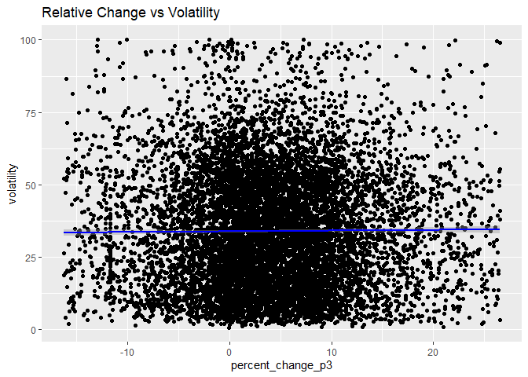

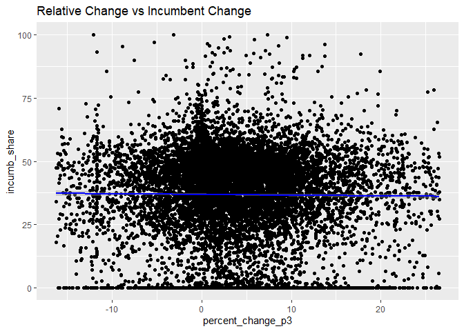

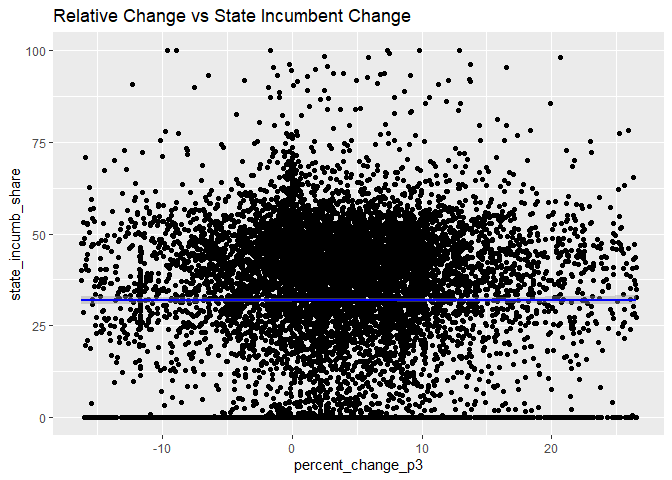

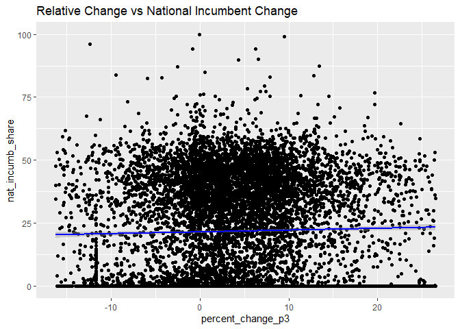

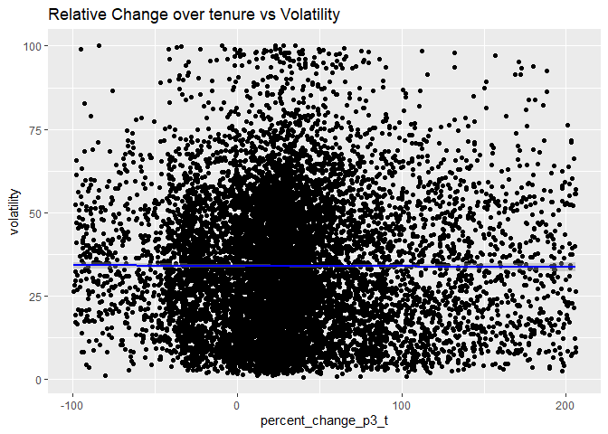

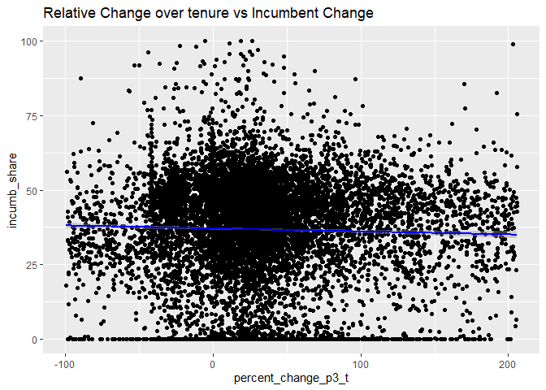

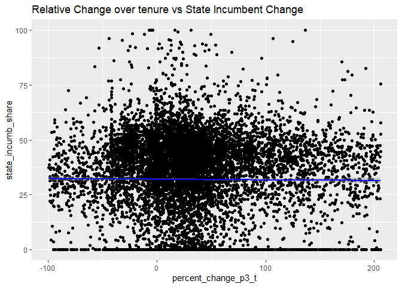

[figure not shown]

| state | ac_name | election_year | volatility | delta_year | nightlights |
| --- | --- | --- | --- | --- | --- |
| ANDHRA PRADESH | ACHAMPET | 1999 | 21.005 | 1998 | 1.709240 |
| ANDHRA PRADESH | ACHAMPET | 2004 | 18.950 | 2003 | 1.943651 |
| ANDHRA PRADESH | ACHANTA | 2004 | 16.120 | 2003 | 7.402138 |
| ANDHRA PRADESH | ADDANKI | 1999 | 54.330 | 1998 | 4.923980 |
| ANDHRA PRADESH | ADDANKI | 2004 | 2.565 | 2003 | 5.721539 |
| ANDHRA PRADESH | ADILABAD | 1999 | 24.390 | 1998 | 3.927750 |
| ANDHRA PRADESH | ADILABAD | 2004 | 43.215 | 2003 | 4.616456 |
| ANDHRA PRADESH | ADONI | 1999 | 5.905 | 1998 | 3.543146 |
| ANDHRA PRADESH | ADONI | 2004 | 22.125 | 2003 | 3.138883 |
| ANDHRA PRADESH | ALAIR | 1999 | 27.285 | 1998 | 6.202911 |

| x |
| --- |
| 6139 |

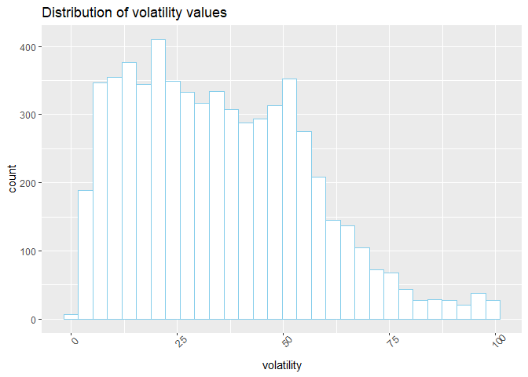

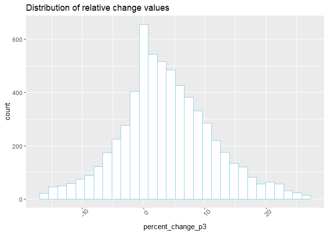

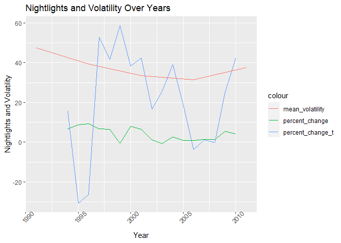

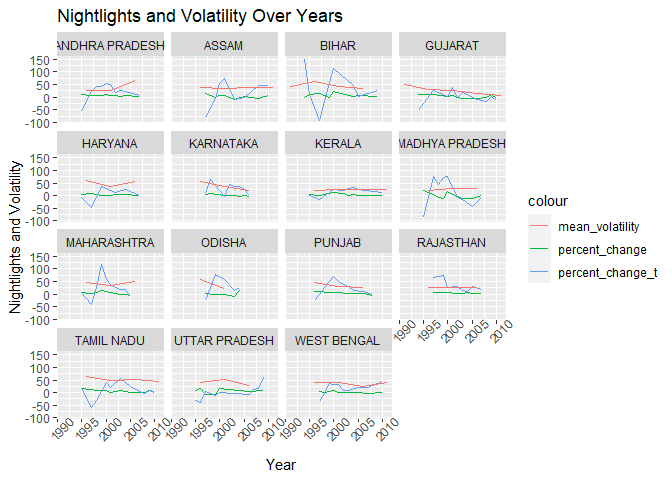

```r
model_rc <- plm(volatility ~ percent_change_p3 + election_year + factor(state), data = filterpanel, index=c("state", "ac_name", "election_year"), model="within")

model_rc2 <- plm(incumb_share ~ percent_change_p3 + election_year + factor(state), data = filterpanel, index=c("state", "ac_name", "election_year"), model="within")

model_rc3 <- plm(state_incumb_share ~ percent_change_p3 + election_year + factor(state), data = filterpanel, index=c("state", "ac_name", "election_year"), model="within")

model_rc4 <- plm(nat_incumb_share ~ percent_change_p3 + election_year + factor(state), data = filterpanel, index=c("state", "ac_name", "election_year"), model="within")

stargazer(model_rc, model_rc2, model_rc3, model_rc4, type="text", report=("vcsp*"), omit=c("state", "election_year"))
```

```
##
## =======================================================================================
##                                                 Dependent variable:
##                             -----------------------------------------------------------
##                             volatility incumb_share state_incumb_share nat_incumb_share
##                                (1)         (2)             (3)               (4)
## ---------------------------------------------------------------------------------------
## percent_change_p3             0.001       0.018           -0.032            -0.053
##                              (0.035)     (0.034)         (0.035)           (0.028)
##                             p = 0.976   p = 0.590       p = 0.357         p = 0.057*
##
## ---------------------------------------------------------------------------------------
## Observations                  6,139       6,139           6,139             6,139
## R2                            0.099       0.045           0.052             0.209
## Adjusted R2                   0.094       0.040           0.048             0.205
## F Statistic (df = 17; 6107) 39.486***   17.001***       19.902***         94.872***
## =======================================================================================
## Note:                                                       *p<0.1; **p<0.05; ***p<0.01
```

```r
model_rc <- plm(volatility ~ percent_change_p3_t + election_year + factor(state), data = filterpanel, index=c("state", "ac_name", "election_year"), model="within")

model_rc2 <- plm(incumb_share ~ percent_change_p3_t + election_year + factor(state), data = filterpanel, index=c("state", "ac_name", "election_year"), model="within")

model_rc3 <- plm(state_incumb_share ~ percent_change_p3_t + election_year + factor(state), data = filterpanel, index=c("state", "ac_name", "election_year"), model="within")

model_rc4 <- plm(nat_incumb_share ~ percent_change_p3_t + election_year + factor(state), data = filterpanel, index=c("state", "ac_name", "election_year"), model="within")

stargazer(model_rc, model_rc2, model_rc3, model_rc4, type="text", report=("vcsp*"), omit=c("state", "election_year"))
```

```
##
## =======================================================================================
##                                                 Dependent variable:
##                             -----------------------------------------------------------
##                             volatility incumb_share state_incumb_share nat_incumb_share
##                                (1)         (2)             (3)               (4)
## ---------------------------------------------------------------------------------------
## percent_change_p3_t           0.005       -0.008          0.001             0.012
##                              (0.006)     (0.006)         (0.006)           (0.005)
##                             p = 0.417   p = 0.173       p = 0.905        p = 0.015**
##
## ---------------------------------------------------------------------------------------
## Observations                  6,139       6,139           6,139             6,139
## R2                            0.099       0.045           0.052             0.209
## Adjusted R2                   0.095       0.041           0.048             0.205
## F Statistic (df = 17; 6107) 39.529***   17.098***       19.850***         95.046***
## =======================================================================================
## Note:                                                       *p<0.1; **p<0.05; ***p<0.01
```

Even this fails! Let’s look at only one electoral cycle. The 2009 general election spotlighted the economy as a key electoral issue. That electoral cycle should indicate a strong correlation.

```r
filterpanel2 <- panel%>%
  filter((cycle == 2011) | (cycle == 2006))
```

| state | ac_name | election_year | volatility | delta_year | nightlights |
| --- | --- | --- | --- | --- | --- |
| ANDHRA PRADESH | CHERIYAL | 2008 | 67.780 | 2007 | 5.8274550 |
| ANDHRA PRADESH | DICHPALLI | 2008 | 62.395 | 2007 | 13.8534431 |
| ANDHRA PRADESH | DOMMAT | 2008 | 82.190 | 2007 | 7.6026640 |
| ANDHRA PRADESH | HUZURABAD | 2008 | 70.150 | 2007 | 9.2247887 |
| ANDHRA PRADESH | JADCHERLA | 2008 | 68.820 | 2007 | 9.3165236 |
| ANDHRA PRADESH | KADIRI | 2014 | 98.045 | 2013 | 4.1346607 |
| ANDHRA PRADESH | KAMALAPUR | 2008 | 78.845 | 2007 | 10.5692101 |
| ANDHRA PRADESH | KAMALAPURAM | 2008 | 78.845 | 2007 | 6.0198660 |
| ANDHRA PRADESH | MUSHEERABAD | 2008 | 38.250 | 2007 | 61.0000038 |
| ANDHRA PRADESH | PADERU | 2014 | 79.820 | 2013 | 0.3785767 |

| x |
| --- |
| 3157 |

```r
model_rc <- plm(volatility ~ percent_change_p3 + election_year*factor(state), data = filterpanel2, index=c("state", "ac_name", "election_year"), model="within")

model_rc2 <- plm(incumb_share ~ percent_change_p3 + election_year*factor(state), data = filterpanel2, index=c("state", "ac_name", "election_year"), model="within")

model_rc3 <- plm(state_incumb_share ~ percent_change_p3 + election_year*factor(state), data = filterpanel2, index=c("state", "ac_name", "election_year"), model="within")

model_rc4 <- plm(nat_incumb_share ~ percent_change_p3 + election_year*factor(state), data = filterpanel2, index=c("state", "ac_name", "election_year"), model="within")

stargazer(model_rc, model_rc2, model_rc3, model_rc4, type="text", report=("vcsp*"), omit=c("state", "election_year"))
```

```
##
## =======================================================================================
##                                                 Dependent variable:
##                             -----------------------------------------------------------
##                             volatility incumb_share state_incumb_share nat_incumb_share
##                                (1)         (2)             (3)               (4)
## ---------------------------------------------------------------------------------------
## percent_change_p3             0.023       0.010           0.057             -0.041
##                              (0.046)     (0.043)         (0.046)           (0.035)
##                             p = 0.618   p = 0.810       p = 0.211         p = 0.242
##
## ---------------------------------------------------------------------------------------
## Observations                  3,157       3,157           3,157             3,157
## R2                            0.052       0.051           0.087             0.225
## Adjusted R2                   0.022       0.021           0.058             0.200
## F Statistic (df = 68; 3060)  2.445***    2.414***        4.268***         13.041***
## =======================================================================================
## Note:                                                       *p<0.1; **p<0.05; ***p<0.01
```

```r
model_rc <- plm(volatility ~ percent_change_p3_t + election_year + factor(state), data = filterpanel2, index=c("state", "ac_name", "election_year"), model="within")

model_rc2 <- plm(incumb_share ~ percent_change_p3_t + election_year + factor(state), data = filterpanel2, index=c("state", "ac_name", "election_year"), model="within")

model_rc3 <- plm(state_incumb_share ~ percent_change_p3_t + election_year + factor(state), data = filterpanel2, index=c("state", "ac_name", "election_year"), model="within")

model_rc4 <- plm(nat_incumb_share ~ percent_change_p3_t + election_year + factor(state), data = filterpanel2, index=c("state", "ac_name", "election_year"), model="within")

stargazer(model_rc, model_rc2, model_rc3, model_rc4, type="text", report=("vcsp*"), omit=c("state", "election_year"))
```

```
##
## =======================================================================================
##                                                 Dependent variable:
##                             -----------------------------------------------------------
##                             volatility incumb_share state_incumb_share nat_incumb_share
##                                (1)         (2)             (3)               (4)
## ---------------------------------------------------------------------------------------
## percent_change_p3_t           0.005       -0.001          0.005             -0.001
##                              (0.007)     (0.006)         (0.007)           (0.006)
##                             p = 0.514   p = 0.908       p = 0.514         p = 0.891
##
## ---------------------------------------------------------------------------------------
## Observations                  3,157       3,157           3,157             3,157
## R2                            0.006       0.020           0.025             0.125
## Adjusted R2                   -0.006      0.008           0.013             0.114
## F Statistic (df = 10; 3118)  1.977**     6.225***        7.877***         44.417***
## =======================================================================================
## Note:                                                       *p<0.1; **p<0.05; ***p<0.01
```

Only negative growth constituencies

```r
filterpanel <- filterpanel%>%
  filter(percent_change_p3 < 0)

model_rc <- plm(volatility ~ percent_change_p3 + election_year + factor(state), data = filterpanel, index=c("state", "ac_name", "election_year"), model="within")

model_rc2 <- plm(incumb_share ~ percent_change_p3 + election_year + factor(state), data = filterpanel, index=c("state", "ac_name", "election_year"), model="within")

model_rc3 <- plm(state_incumb_share ~ percent_change_p3 + election_year + factor(state), data = filterpanel, index=c("state", "ac_name", "election_year"), model="within")

model_rc4 <- plm(nat_incumb_share ~ percent_change_p3 + election_year + factor(state), data = filterpanel, index=c("state", "ac_name", "election_year"), model="within")

stargazer(model_rc, model_rc2, model_rc3, model_rc4, type="text", report=("vcsp*"), omit=c("state", "election_year"))
```

```
##
## =======================================================================================
##                                                 Dependent variable:
##                             -----------------------------------------------------------
##                             volatility incumb_share state_incumb_share nat_incumb_share
##                                (1)         (2)             (3)               (4)
## ---------------------------------------------------------------------------------------
## percent_change_p3             -0.067      0.299           0.025             0.057
##                              (0.117)     (0.105)         (0.113)           (0.092)
##                             p = 0.565  p = 0.005***     p = 0.823         p = 0.538
##
## ---------------------------------------------------------------------------------------
## Observations                  1,855       1,855           1,855             1,855
## R2                            0.115       0.068           0.068             0.174
## Adjusted R2                   0.100       0.052           0.052             0.160
## F Statistic (df = 17; 1823) 13.979***    7.849***        7.831***         22.628***
## =======================================================================================
## Note:                                                       *p<0.1; **p<0.05; ***p<0.01
```

```r
model_rc <- plm(volatility ~ percent_change_p3_t + election_year + factor(state), data = filterpanel, index=c("state", "ac_name", "election_year"), model="within")

model_rc2 <- plm(incumb_share ~ percent_change_p3_t + election_year + factor(state), data = filterpanel, index=c("state", "ac_name", "election_year"), model="within")

model_rc3 <- plm(state_incumb_share ~ percent_change_p3_t + election_year + factor(state), data = filterpanel, index=c("state", "ac_name", "election_year"), model="within")

model_rc4 <- plm(nat_incumb_share ~ percent_change_p3_t + election_year + factor(state), data = filterpanel, index=c("state", "ac_name", "election_year"), model="within")

stargazer(model_rc, model_rc2, model_rc3, model_rc4, type="text", report=("vcsp*"), omit=c("state", "election_year"))
```

```
##
## =======================================================================================
##                                                 Dependent variable:
##                             -----------------------------------------------------------
##                             volatility incumb_share state_incumb_share nat_incumb_share
##                                (1)         (2)             (3)               (4)
## ---------------------------------------------------------------------------------------
## percent_change_p3_t           0.025       -0.032          0.004             0.013
##                              (0.013)     (0.012)         (0.013)           (0.010)
##                             p = 0.059* p = 0.007***     p = 0.769         p = 0.210
##
## ---------------------------------------------------------------------------------------
## Observations                  1,855       1,855           1,855             1,855
## R2                            0.117       0.068           0.068             0.175
## Adjusted R2                   0.102       0.052           0.052             0.161
## F Statistic (df = 17; 1823) 14.196***    7.808***        7.833***         22.713***
## =======================================================================================
## Note:                                                       *p<0.1; **p<0.05; ***p<0.01
```